# Practical Machine Learning Course Project

# Machine Learning Algorithm #2 : Neural Network

In machine learning and cognitive science, artificial neural networks (ANNs) are a family of models inspired by biological neural networks (the central nervous systems of animals, in particular the brain) and are used to estimate or approximate functions that can depend on a large number of inputs and are generally unknown. Artificial neural networks are generally presented as systems of interconnected “neurons” which exchange messages between each other. The connections have numeric weights that can be tuned based on experience, making neural nets adaptive to inputs and capable of learning.

We are going to use the scaled data.

```r
trainingNN <- as.data.frame(trainingKnn)
testingNN <- as.data.frame(testingKnn)
```

After a few try to fit the neural network with all of remaining variables, neither Rprop or backpropagation algorithm converge. That can be dut to the fact that there is not enough variation in how data. We will try to create principal component analysis and only keep variables causing variation.

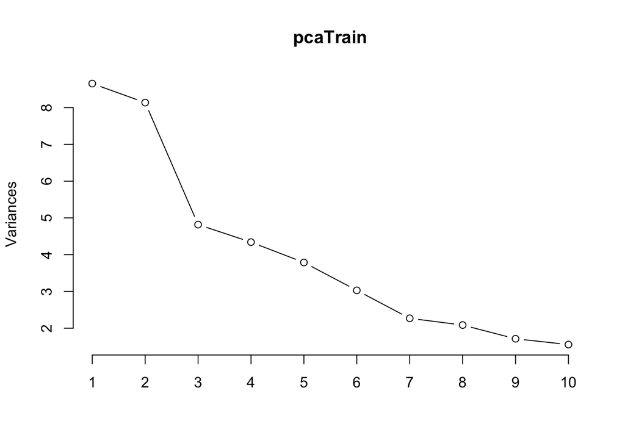

```r
yTrain <- as.data.frame(trainingNN[,"V56"])
pcaTrain <- prcomp(trainingNN[,-ncol(trainingNN)])
pcaTesting <- prcomp(testingNN[,-ncol(testingNN)])
plot(pcaTrain, type = "l")
```

```r
trainingANN <- as.data.frame(pcaTrain$x[,1:20])
trainingANN$y <- data.frame("y" = yTrain)
testingANN <- as.data.frame(pcaTesting$x[,1:20])

n <- names(trainingANN)
f <- as.formula(paste("A+B+C+D+E~", paste(n[!n %in% "y"], collapse = " + ")))

# Binarize the categorical output

trainingANN <- cbind(trainingANN, trainingANN$y == 1)
trainingANN <- cbind(trainingANN, trainingANN$y == 2)
trainingANN <- cbind(trainingANN, trainingANN$y == 3)
trainingANN <- cbind(trainingANN, trainingANN$y == 4)
trainingANN <- cbind(trainingANN, trainingANN$y == 5)

names(trainingANN)[22] <- "A"
names(trainingANN)[23] <- "B"
names(trainingANN)[24] <- "C"
names(trainingANN)[25] <- "D"
names(trainingANN)[26] <- "E"

trainingANN <- trainingANN[,-21]

# Fit the model

nn <-  neuralnet(f,
               data = trainingANN, hidden = 2,
               err.fct = "sse", linear.output = F)

# Predict
pred.nn <- compute(nn, testingANN)$net.result

predann <- c()

for(i in 1:nrow(pred.nn)){
    predann[i] <- which.max(pred.nn[i,])[[1]]
}

testingNN$pred <- predann

# Table
confusionMatrix(predann, testingNN$V56)
```

```
## Confusion Matrix and Statistics
##
##           Reference
## Prediction   1   2   3   4   5
##          1 662 350 341 214 259
##          2 196 244 115 250 236
##          3 503 273 348 213 247
##          4   0   0   0   0   0
##          5 313 272 222 287 340
##
## Overall Statistics
##
##                Accuracy : 0.2708581
##                  95% CI : (0.2595349, 0.2824089)
##     No Information Rate : 0.284452
##     P-Value [Acc > NIR] : 0.9902381
##
##                   Kappa : 0.0720766
##  Mcnemar's Test P-Value : < 0.00000000000000022
##
## Statistics by Class:
##
##                       Class: 1   Class: 2   Class: 3  Class: 4  Class: 5
## Sensitivity          0.3954600 0.21422300 0.33918129 0.0000000 0.3142329
## Specificity          0.7235811 0.83206911 0.74562667 1.0000000 0.7722257
## Pos Pred Value       0.3625411 0.23439001 0.21969697       NaN 0.2370990
## Neg Pred Value       0.7506775 0.81523534 0.84236224 0.8361937 0.8332959
## Prevalence           0.2844520 0.19354291 0.17434155 0.1638063 0.1838573
## Detection Rate       0.1124894 0.04146134 0.05913339 0.0000000 0.0577740
## Detection Prevalence 0.3102804 0.17689040 0.26915888 0.0000000 0.2436703
## Balanced Accuracy    0.5595205 0.52314606 0.54240398 0.5000000 0.5432293
```

```r
mean(predann == testingNN$V56)
```

```
## [1] 0.2708581138
```

As you can see the result is not good. It’s possibly because of bad specification of the data.

# Machine Learning Algorithm #3: Random Forest

Random forests is a notion of the general technique of random decision forests that are an ensemble learning method for classification, regression and other tasks, that operate by constructing a multitude of decision trees at training time and outputting the class that is the mode of the classes (classification) or mean prediction (regression) of the individual trees. Random decision forests correct for decision trees’ habit of overfitting to their training set.

```r
knitr::opts_chunk$set(cache=TRUE)
# Random Forest ----------------------------------------------------------------
set.seed(1)
modelFit <- randomForest(as.factor(classe)~., data=training, importance = TRUE, mtry = 15, ntree = 250)

# Predict
pred <- predict(modelFit, testing[,-c(58)])
testing$predRight <- pred==testing$classe
mean(pred == testing$classe)
```

```
## [1] 0.9989804588
```

```r
table(pred, testing$classe)
```

```
##
## pred    A    B    C    D    E
##    A 1674    0    0    0    0
##    B    0 1139    2    0    0
##    C    0    0 1023    1    0
##    D    0    0    1  962    1
##    E    0    0    0    1 1081
```